# 41 Integration by parts

This section uses these add-on packages:

```julia
using CalculusWithJulia
using Plots; plotly()
using SymPy
```

So far we have seen that the *derivative* rules lead to *integration rules*. In particular:

- The sum rule $[au(x) + bv(x)]' = au'(x) + bv'(x)$ gives rise to an integration rule: $\int (au(x) + bv(x))dx = a\int u(x)dx + b\int v(x))dx$. (That is, the linearity of the derivative means the integral has linearity.)
- The chain rule $[g(u(x))]' = g'(u(x)) u'(x)$ gives $\int_a^b g(u(x))u'(x)dx=\int_{u(a)}^{u(b)}g(x)dx$. That is, $u$-substitution reverses the chain rule.

Now we turn our attention to the implications of the *product rule*: $[uv]' = u'v + uv'$. The resulting technique is called integration by parts.

**DefinitionIntegration by parts**

By the fundamental theorem of calculus:

$$\begin{align*}
\left[u(x)\cdot v(x)\right]\Big|_a^b &= \int_a^b [u(x) v(x)]' dx\\
&= \int_a^b u'(x) \cdot v(x) dx + \int_a^b u(x) \cdot v'(x) dx.
\end{align*}$$

Or,

$$\int_a^b u(x) v'(x) dx = \left[u(x)v(x)\right]\Big|_a^b - \int_a^b v(x) u'(x)dx.$$

Figure 41.1 illustrates integration by parts showing a parametric plot of $(u(t),v(t))$ for $a \leq t \leq b$.

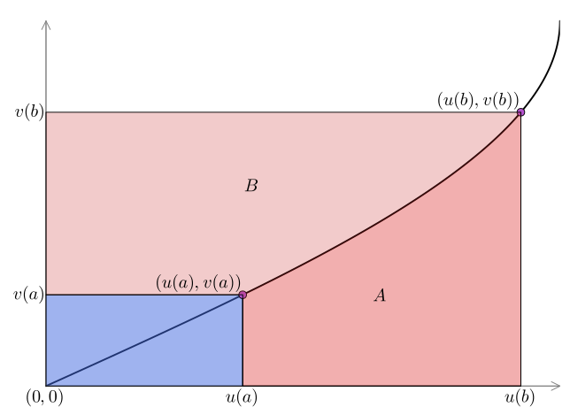

Figure 41.1: Integration by parts figure ([original](http://en.wikipedia.org/wiki/Integration_by_parts#Visualization))

The total shaded area, a rectangle, is $u(b)v(b)$, the area of $A$ and $B$ combined is just $u(b)v(b) - u(a)v(a)$ or $[u(x)v(x)]\Big|_a^b$. We will show that $A$ is $\int_a^b v(x)u'(x)dx$ and $B$ is $\int_a^b u(x)v'(x)dx$ giving the formula.

We can compute $A$ by a change of variables with $x=u^{-1}(t)$ (so $u'(x)dx = dt$):

$$\begin{align*}
A &= \int_{u(a)}^{u(b)} v(u^{-1}(t)) dt & \text{let } x = u^{-1}(t) \text{ or }u(x) = t \\
&= \int_{u^{-1}(u(a))}^{u^{-1}(u(b))} v(x) u'(x) dx \\
&= \int_a^b v(x) u'(x) dx.
\end{align*}$$

$B$ is similar with the roles of $u$ and $v$ reversed.

Informally, the integration by parts formula is sometimes seen as $\int udv = uv - \int v du$, as well can be somewhat confusingly written as:

$$\int f(x) g'(x) dx = f(x)g(x) - \int f'(x) g(x) dx.$$

(The confusion coming from the fact that the indefinite integrals are only defined up to a constant.)

How does this formula help? It allows us to differentiate parts of an integral in hopes it makes the result easier to integrate.

An illustration can clarify.

Consider the integral $\int_0^\pi x\sin(x) dx$. If we let $u=x$ and $dv=\sin(x) dx$, then $du = 1dx$ and $v=-\cos(x)$. The above then says:

$$\begin{align*}
\int_0^\pi x\sin(x) dx &= \int_0^\pi u dv\\
&= uv\Big|_0^\pi - \int_0^\pi v du\\
&= x \cdot (-\cos(x)) \Big|_0^\pi - \int_0^\pi (-\cos(x)) dx\\
&= \pi (-\cos(\pi)) - 0(-\cos(0)) + \int_0^\pi \cos(x) dx\\
&= \pi + \sin(x)\Big|_0^\pi\\
&= \pi.
\end{align*}$$

The technique means one part is differentiated and one part integrated. The art is to break the integrand up into a piece that gets easier through differentiation and a piece that doesn’t get much harder through integration.

#### Examples

Consider $\int_1^2 x \log(x) dx$. We might try differentiating the $\log(x)$ term, so we set

$$u=\log(x) \text{ and } dv=xdx$$

Then we get

$$du = \frac{1}{x} dx \text{ and } v = \frac{x^2}{2}.$$

Putting together gives:

$$\begin{align*}
\int_1^2 x \log(x) dx
&= (\log(x) \cdot \frac{x^2}{2}) \Big|_1^2 - \int_1^2 \frac{x^2}{2} \frac{1}{x} dx\\
&= (2\log(2) - 0) - (\frac{x^2}{4})\Big|_1^2\\
&= 2\log(2) - (1 - \frac{1}{4}) \\
&= 2\log(2) - \frac{3}{4}.
\end{align*}$$

##### Example

This related problem, $\int \log(x) dx$, uses the same idea, though perhaps harder to see at first glance, as setting `dv=dx` is almost too simple to try:

$$\begin{align*}
u &= \log(x) & dv &= dx\\
du &= \frac{1}{x}dx & v &= x
\end{align*}$$

$$\begin{align*}
\int \log(x) dx
&= \int u dv\\
&= uv - \int v du\\
&= (\log(x) \cdot x) - \int x \cdot \frac{1}{x} dx\\
&= x \log(x) - \int dx\\
&= x \log(x) - x
\end{align*}$$

Were this a definite integral problem, we would have written:

$$\int_a^b \log(x) dx = (x\log(x))\Big|_a^b - \int_a^b dx = (x\log(x) - x)\Big|_a^b.$$

##### Example

Sometimes integration by parts is used two or more times. Here we let $u=x^2$ and $dv = e^x dx$:

$$\int_a^b x^2 e^x dx = (x^2 \cdot e^x)\Big|_a^b - \int_a^b 2x e^x dx.$$

But we can compute $\int_a^b x e^xdx$ the same way:

$$\int_a^b x e^x = (x\cdot e^x)\Big|_a^b - \int_a^b 1 \cdot e^xdx = (xe^x - e^x)\Big|_a^b.$$

Combining gives the answer:

$$\int_a^b x^2 e^x dx
= (x^2 \cdot e^x)\Big|_a^b - 2( (xe^x - e^x)\Big|_a^b ) =
e^x(x^2 - 2x + 2) \Big|_a^b.$$

In fact, it isn’t hard to see that an integral of $x^m e^x$, $m$ a positive integer, can be handled in this manner. For example, when $m=10$, `SymPy` gives:

```julia
@syms x
integrate(x^10 * exp(x), x)
```

$\left(x^{10} - 10 x^{9} + 90 x^{8} - 720 x^{7} + 5040 x^{6} - 30240 x^{5} + 151200 x^{4} - 604800 x^{3} + 1814400 x^{2} - 3628800 x + 3628800\right) e^{x}$

The general answer is $\int x^n e^xdx = p(x) e^x$, where $p(x)$ is a polynomial of degree $n$.

##### Example

The same technique is attempted for the integral of $e^x\sin(x)$, but ends differently.

First we let $u=\sin(x)$ and $dv=e^x dx$, then

$$du = \cos(x)dx \quad \text{and}\quad v = e^x.$$

So:

$$\int e^x \sin(x)dx = \sin(x) e^x - \int \cos(x) e^x dx.$$

Now we let $u = \cos(x)$ and again $dv=e^x dx$, then

$$du = -\sin(x)dx \quad \text{and}\quad v = e^x.$$

So:

$$\begin{align*}
\int e^x \sin(x)dx &= \sin(x) e^x - \int \cos(x) e^x dx \\
&= \sin(x)e^x - \cos(x)e^x + \int (-\sin(x))e^x dx.
\end{align*}$$

But simplifying this gives:

$$\int e^x \sin(x)dx = - \int e^x \sin(x)dx + e^x(\sin(x) - \cos(x)).$$

Solving for the “unknown” $\int e^x \sin(x) dx$ gives:

$$\int e^x \sin(x) dx = \frac{1}{2} e^x (\sin(x) - \cos(x)).$$

##### Example

Positive integer powers of trigonometric functions can be addressed by this technique. Consider $\int \cos(x)^n dx$. We let $u=\cos(x)^{n-1}$ and $dv=\cos(x) dx$. Then $du = (n-1)\cos(x)^{n-2}(-\sin(x))dx$ and $v=\sin(x)$. So,

$$\begin{align*}
\int \cos(x)^n dx &= \cos(x)^{n-1} \cdot (\sin(x)) + \int (\sin(x)) ((n-1)\sin(x) \cos(x)^{n-2}) dx \\
&= \sin(x) \cos(x)^{n-1} + (n-1)\int \sin^2(x) \cos(x)^{n-2} dx\\
&= \sin(x) \cos(x)^{n-1} + (n-1)\int (1 - \cos(x)^2) \cos(x)^{n-2} dx\\
&= \sin(x) \cos(x)^{n-1} + (n-1)\int \cos(x)^{n-2}dx - (n-1)\int \cos(x)^n dx.
\end{align*}$$

We can then solve for the unknown ($\int \cos(x)^{n}dx$) to get this *reduction formula*:

$$\int \cos(x)^n dx = \frac{1}{n}\sin(x) \cos(x)^{n-1} + \frac{n-1}{n}\int \cos(x)^{n-2}dx.$$

`SymPy` is willing and able to do this repeated bookkeeping. For example with $n=10$:

```julia
integrate(cos(x)^10, x)
```

$\frac{63 x}{256} + \frac{\sin{\left(x \right)} \cos^{9}{\left(x \right)}}{10} + \frac{9 \sin{\left(x \right)} \cos^{7}{\left(x \right)}}{80} + \frac{21 \sin{\left(x \right)} \cos^{5}{\left(x \right)}}{160} + \frac{21 \sin{\left(x \right)} \cos^{3}{\left(x \right)}}{128} + \frac{63 \sin{\left(x \right)} \cos{\left(x \right)}}{256}$

##### Example

The visual interpretation of integration by parts breaks area into two pieces, the one labeled “B” looks like it would be labeled “A” for an inverse function for $f$. Indeed, integration by parts gives a means to possibly find antiderivatives for inverse functions.

Let $uv = x f^{-1}(x)$. Then we have $[uv]' = u'v + uv' = f^{-1}(x) + x [f^{-1}(x)]'$. So, up to a constant $uv = \int [uv]'dx = \int f^{-1}(x)dx + \int x [f^{-1}(x)]'dx$. Re-expressing gives:

$$\begin{align*}
\int f^{-1}(x) dx
&= xf^{-1}(x) - \int x [f^{-1}(x)]' dx\\
&= xf^{-1}(x) - \int f(u) du.\\
\end{align*}$$

The last line follows from the $u$-substitution: $u=f^{-1}(x)$ for then $du = [f^{-1}(x)]' dx$ and $x=f(u)$.

We use this to find an antiderivative for $\sin^{-1}(x)$:

$$\begin{align*}
\int \sin^{-1}(x) dx &= x \sin^{-1}(x) - \int \sin(u) du \\
&= x \sin^{-1}(x) + \cos(u) \\
&= x \sin^{-1}(x) + \cos(\sin^{-1}(x)).
\end{align*}$$

Using right triangles to simplify, the last value $\cos(\sin^{-1}(x))$ can otherwise be written as $\sqrt{1 - x^2}$.

##### Example: maximum error in the trapezoid rule

The [trapezoid](http://en.wikipedia.org/wiki/Trapezoidal_rule) rule is an approximation to the definite integral like a Riemann sum, only instead of approximating the area above $[x_i, x_i + h]$ by a rectangle with height $f(c_i)$ (for some $c_i$), it uses a trapezoid formed by the left and right endpoints. That is, this area is used in the estimation: $(1/2)\cdot (f(x_i) + f(x_i+h)) \cdot h$.

Even though we suggest just using `quadgk` for numeric integration, estimating the error in this approximation is of theoretical interest.

Recall, just using *either* $x_i$ or $x_{i-1}$ for $c_i$ gives an error that is “like” $1/n$, as $n$ gets large, though the exact rate depends on the function and the length of the interval.

This [proof](http://www.math.ucsd.edu/~ebender/20B/77_Trap.pdf) for the error estimate is involved, but is reproduced here, as it nicely integrates many of the theoretical concepts of integration discussed so far.

First, for convenience, we consider the interval $x_i$ to $x_i+h$. The actual answer over this is just $\int_{x_i}^{x_i+h}f(x) dx$. By a $u$-substitution with $u=x-x_i$ this becomes $\int_0^h f(t + x_i) dt$. For analyzing this we integrate once by parts using $u=f(t+x_i)$ and $dv=dt$. But instead of letting $v=t$, we choose to add—as is our prerogative—a constant of integration $A$, so $v=t+A$:

$$\begin{align*}
\int_0^h f(t + x_i) dt &= uv \Big|_0^h - \int_0^h v du\\
&= f(t+x_i)(t+A)\Big|_0^h - \int_0^h (t + A) f'(t + x_i) dt.
\end{align*}$$

To compute this, we *again* integrate by parts with

$$\begin{align*}
u &= f'(t + x_i) & dv &= (t + A)dt\\
du &= f''(t + x_i) & v &= \frac{(t + A)^2}{2} + B
\end{align*}$$

Again we added a constant of integration, $B$, to $v$. The error becomes:

$$\begin{align*}
\text{error}_i &= -\left(\frac{(t+A)^2}{2} + B\right)f'(t+x_i)\Big|_0^h \\
&\quad + \int_0^h \left(\frac{(t+A)^2}{2} + B\right) \cdot f''(t+x_i) dt.
\end{align*}$$

With $A=-h/2$, $B$ is chosen so $(t+A)^2/2 + B = 0$ at endpoints, or $B=-h^2/8$. The error becomes

$$\text{error}_i = \int_0^h \left(\frac{(t-h/2)^2}{2} - \frac{h^2}{8}\right) \cdot f''(t + x_i) dt.$$

Now, we assume the $\lvert f''(t)\rvert$ is bounded by $K$ for any $a \leq t \leq b$. This will be true, for example, if the second derivative is assumed to exist and be continuous. Using this fact about definite integrals $\lvert \int_a^b g dx\rvert \leq \int_a^b \lvert g \rvert dx$ we have:

$$\lvert \text{error}_i \rvert \leq K \int_0^h \lvert \left(\frac{(t-h/2)^2}{2} - \frac{h^2}{8}\right) \rvert dt.$$

But what is the function in the integrand? Clearly it is a quadratic in $t$. Expanding gives $1/2 \cdot (t^2 - ht)$. This is negative over $[0,h]$ (and $0$ at these endpoints, so the integral above is just:

$$\frac{1}{2}\int_0^h (ht - t^2)dt = \frac{1}{2} \left(\frac{ht^2}{2} - \frac{t^3}{3}\right)\Big|_0^h = \frac{h^3}{12}$$

This gives the bound: $\vert \text{error}_i \rvert \leq K h^3/12$. The *total* error may be less, but is not more than the value found by adding up the error over each of the $n$ intervals. As our bound does not depend on the $i$, we have this sum satisfies:

$$\lvert \text{error}\rvert \leq n \cdot \frac{Kh^3}{12} = \frac{K(b-a)^3}{12}\frac{1}{n^2}.$$

So the maximum error[^1] is like $1/n^2$, in contrast to the $1/n$ error of the Riemann sums. One way to see this, for the Riemann sum it takes twice as many terms to half an error estimate, but for the trapezoid rule only $\sqrt{2}$ as many, and for Simpson’s rule, only $2^{1/4}$ as many.

## 41.1 Area related to parameterized curves

The figure introduced to motivate the integration by parts formula also suggests that areas described parametrically (by a pair of functions $x=u(t), y=v(t)$ for $a \le t \le b$) can have their area computed.

When $u(t)$ is strictly *increasing*, and hence having an inverse function, then re-parameterizing by $\phi(t) = u^{-1}(t)$ gives a $x=u(u^{-1}(t))=t, y=v(u^{-1}(t))$ and integrating this gives the area by $A=\int_a^b v(t) u'(t) dt$

However, the correct answer requires understanding a minus sign. Consider the area enclosed by $x(t) = \cos(t), y(t) = \sin(t)$ in Figure 41.2.

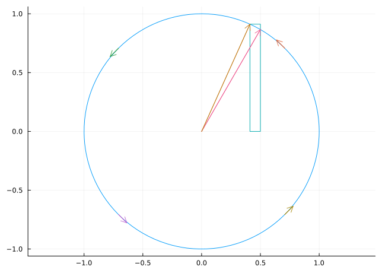

Figure 41.2: Area consideration for a parameterized curve

Taking this Riemann sum approach, we can approximate the area under the curve parameterized by $(u(t), v(t))$ over the time range $[t_i, t_{i+1}]$ as a rectangle with height $y(t_i)$ and base $x(t_{i}) - x(t_{i+1})$. Then we get, as expected:

$$\begin{align*}
A &\approx \sum_i y(t_i) \cdot (x(t_{i}) - x(t_{i+1}))\\
&= - \sum_i y(t_i) \cdot (x(t_{i+1}) - x(t_{i}))\\
&= - \sum_i y(t_i) \cdot \frac{x(t_{i+1}) - x(t_i)}{t_{i+1}-t_i} \cdot (t_{i+1}-t_i)\\
&\approx -\int_a^b y(t) x'(t) dt\\
&= \int_a^b x(t) y'(t) dt.
\end{align*}$$

The last line using integration by parts to reverse the role of $x$ and $y$. When traversing a curve in a counter clockwise manner $\int x(t) y'(t) dt$ has no minus sign and when traversing in a clockwise manner $\int y(t) x'(t) dt$ has no minus sign.

This is a case of [Green’s Theorem](https://en.wikipedia.org/wiki/Green%27s_theorem#Area_calculation) to be taken up in Green’s Theorem, Stokes’ Theorem, and the Divergence Theorem.

We also revisit this in the section on the area between curves where this formula comes from decomposing the area contained within a simple polygon using trapezoids.

##### Example

Apply the formula to a parameterized circle to ensure, the signed area is properly computed. If we use $x(t) = r\cos(t)$ and $y(t) = r\sin(t)$ then we have the motion is counterclockwise:

```julia
@syms r t
x = r * cos(t)
y = r * sin(t)
integrate(x * diff(y, t), (t, 0, 2PI))
```

$\pi r^{2}$

We see the expected answer for the area of a circle.

##### Example

Apply the formula to find the area under one arch of a cycloid, parameterized by $x(t) = t - \sin(t), y(t) = 1 - \cos(t)$.

Working symbolically, we have one arch given by the following described in a *clockwise* manner, so we use $\int y(t) x'(t) dt$:

```julia
@syms t
x = t - sin(t)
y = 1 - cos(t)
integrate(y * diff(x, t), (t, 0, 2PI))
```

$3 \pi$

([Galileo](https://mathshistory.st-andrews.ac.uk/Curves/Cycloid/) was thwarted in finding this answer exactly and resorted to constructing one from metal to *estimate* the value.)

##### Example

Consider the example $x(t) = \cos(t) + t\sin(t), y(t) = \sin(t) - t\cos(t)$ for $0 \leq t \leq 2\pi$ shown in Figure 41.3.

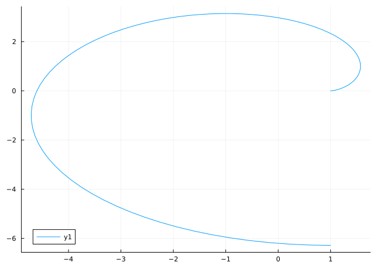

Figure 41.3: Plot of parameterized spiraling curve over $[0, 2\pi]$

How much area is enclosed by this curve and the $x$ axis? The area is described in a counterclockwise manner, so we have:

```julia
let # a let block avoids the issue that `x` has already been used as a constant
    x(t) = cos(t) + t*sin(t)
    y(t) = sin(t) - t*cos(t)
    xy′(t) = x(t) * y'(t)  # xy\prime[tab]
    quadgk(xy′, 0, 2pi)
end
```

```
(38.20010958680997, 1.8584320904402318e-7)
```

This particular problem could also have been done symbolically, but many curves will need to have a numeric approximation used.

## 41.2 Questions

###### Question

In the integral of $\int \log(x) dx$ we let $u=\log(x)$ and $dv=dx$. What are $du$ and $v$?

\(du=1/x dx \quad v = x\)

\(du=1/x dx\quad v = x^2/2\)

\(du=x\log(x) dx\quad v = 1\)

###### Question

In the integral $\int \sec(x)^3 dx$ we let $u=\sec(x)$ and $dv = \sec(x)^2 dx$. What are $du$ and $v$?

\(du=\sec(x)\tan(x)dx \quad v=\tan(x)\)

\(du=\tan(x) dx \quad v=\sec(x)\tan(x)\)

\(du=\csc(x) dx \quad v=\sec(x)^3 / 3\)

###### Question

In the integral $\int e^{-x} \cos(x)dx$ we let $u=e^{-x}$ and $dv=\cos(x) dx$. What are $du$ and $v$?

\(du=-e^{-x} dx \quad v=\sin(x)\)

\(du=-e^{-x} dx \quad v=-\sin(x)\)

\(du=\sin(x)dx \quad v=-e^{-x}\)

###### Question

Find the value of $\int_1^4 x \log(x) dx$. You can integrate by parts.

###### Question

Find the value of $\int_0^{\pi/2} x\cos(2x) dx$. You can integrate by parts.

###### Question

Find the value of $\int_1^e (\log(x))^2 dx$. You can integrate by parts.

###### Question

Integration by parts can be used to provide “reduction” formulas, where an antiderivative is written in terms of another antiderivative with a lower power. Which is the proper reduction formula for $\int (\log(x))^n dx$?

\(x(\log(x))^n - n \int (\log(x))^{n-1} dx\)

\(x(\log(x))^n - \int (\log(x))^{n-1} dx\)

\(\int (\log(x))^{n+1}/(n+1) dx\)

###### Question

Let $k$ be a positive integer. We can use integration by parts to understand the value of

$$I_k = \int x^k \exp(-x) dx$$

Let $u = x^k$ and $dv = \exp(-x)$. What becomes of $uv$?

What becomes of $\int v du$?

Does this show that $I_k = -x^k \exp(-x) + k I_{k-1}$?

If so them be repeating the above until $k=0$, we can see that $I_k = p_k \exp(-x)$ for some polynomial $p_k$ of degree $k$.

###### Question

The [Wikipedia](http://en.wikipedia.org/wiki/Integration_by_parts) page has a rule of thumb with an acronym LIATE to indicate what is a good candidate to be “$u$”: **L**og function, **I**nverse functions, **A**lgebraic functions ($x^n$), **T**rigonmetric functions, and **E**xponential functions.

Consider the integral $\int x \cos(x) dx$. Which letter should be tried first?

L

I

A

T

E

Consider the integral $\int x^2\log(x) dx$. Which letter should be tried first?

L

I

A

T

E

Consider the integral $\int x^2 \sin^{-1}(x) dx$. Which letter should be tried first?

L

I

A

T

E

Consider the integral $\int e^x \sin(x) dx$. Which letter should be tried first?

L

I

A

T

E

###### Question

Find an antiderivative for $\cos^{-1}(x)$ using the integration by parts formula.

\(x\cos^{-1}(x)-\sqrt{1 - x^2}\)

\(x^2/2 \cos^{-1}(x) - x\sqrt{1-x^2}/4 - \cos^{-1}(x)/4\)

\(-\sin^{-1}(x)\)

###### Question

In [notes by S.G. Johnson](https://math.mit.edu/~stevenj/trap-iap-2011.pdf) we find a simpler means to estimate the maximum error in the (composite) trapezoid rule.

Each trapezoid estimate uses a line between two points, $x_{i-1}$ and $x_i$ so deviates from a Taylor polynomial how?

The worst case error in a single approximation is then around $\Delta_x^2$ times a constant depending on $f''$.

The error in the approximation—up to a constant—over the interval is:

In terms of $n$, the error in each sub-interval is like $1/n^3$. The total error in the approximation is then

This is a worst case estimate, of course, as it doesn’t account for individual errors canceling each other off.

[^1]: This is a worst-case estimate. There are functions for which the trapezoid method converges exponentially and are discussed in [Trefethen and Weiderman](https://people.maths.ox.ac.uk/trefethen/sirev56-3_385.pdf).